# Final Project

Data Science for Biologists, Spring 2021

Caitlyn Angley

## Introduction

The data I chose is Women in the Workplace. I chose this data set because I have always been interested in the differences between men and women in the workplace, especially dealing with wages. This data set includes data about wages earned by men vs. women, what sectors they work in, as well as who is working part-time or full-time. [Link to the Data!](https://github.com/rfordatascience/tidytuesday/tree/master/data/2019/2019-03-05)

```r
jobs_gender <- readr::read_csv("https://raw.githubusercontent.com/rfordatascience/tidytuesday/master/data/2019/2019-03-05/jobs_gender.csv")
earnings_female <- readr::read_csv("https://raw.githubusercontent.com/rfordatascience/tidytuesday/master/data/2019/2019-03-05/earnings_female.csv")
employed_gender <- readr::read_csv("https://raw.githubusercontent.com/rfordatascience/tidytuesday/master/data/2019/2019-03-05/employed_gender.csv")

glimpse(earnings_female) #looking at each dataset
```

```
## Rows: 264
## Columns: 3
## $ Year    <dbl> 1979, 1980, 1981, 1982, 1983, 1984, 1985, 1986, 1987, 1988, 1…
## $ group   <chr> "Total, 16 years and older", "Total, 16 years and older", "To…
## $ percent <dbl> 62.3, 64.2, 64.4, 65.7, 66.5, 67.6, 68.1, 69.5, 69.8, 70.2, 7…
```

```r
glimpse(employed_gender)
```

```
## Rows: 49
## Columns: 7
## $ year             <dbl> 1968, 1969, 1970, 1971, 1972, 1973, 1974, 1975, 1976…
## $ total_full_time  <dbl> 86.0, 85.5, 84.8, 84.4, 84.3, 84.4, 84.2, 83.4, 83.3…
## $ total_part_time  <dbl> 14.0, 14.5, 15.2, 15.6, 15.7, 15.6, 15.8, 16.6, 16.7…
## $ full_time_female <dbl> 75.1, 74.9, 73.9, 73.2, 73.1, 73.2, 73.2, 72.4, 72.5…
## $ part_time_female <dbl> 24.9, 25.1, 26.1, 26.8, 26.9, 26.8, 26.8, 27.6, 27.5…
## $ full_time_male   <dbl> 92.2, 91.8, 91.5, 91.2, 91.1, 91.4, 91.2, 90.6, 90.6…
## $ part_time_male   <dbl> 7.8, 8.2, 8.5, 8.8, 8.9, 8.6, 8.8, 9.4, 9.4, 9.5, 9.…
```

```r
glimpse(jobs_gender)
```

```
## Rows: 2,088
## Columns: 12
## $ year                  <dbl> 2013, 2013, 2013, 2013, 2013, 2013, 2013, 2013,…
## $ occupation            <chr> "Chief executives", "General and operations man…
## $ major_category        <chr> "Management, Business, and Financial", "Managem…
## $ minor_category        <chr> "Management", "Management", "Management", "Mana…
## $ total_workers         <dbl> 1024259, 977284, 14815, 43015, 754514, 44198, 1…
## $ workers_male          <dbl> 782400, 681627, 8375, 17775, 440078, 16141, 728…
## $ workers_female        <dbl> 241859, 295657, 6440, 25240, 314436, 28057, 368…
## $ percent_female        <dbl> 23.6, 30.3, 43.5, 58.7, 41.7, 63.5, 33.6, 27.5,…
## $ total_earnings        <dbl> 120254, 73557, 67155, 61371, 78455, 74114, 6218…
## $ total_earnings_male   <dbl> 126142, 81041, 71530, 75190, 91998, 90071, 6657…
## $ total_earnings_female <dbl> 95921, 60759, 65325, 55860, 65040, 66052, 55079…
## $ wage_percent_of_male  <dbl> 76.04208, 74.97316, 91.32532, 74.29179, 70.6971…
```

## Question 1

#### How has female full-time employment changed over time?

### Methods

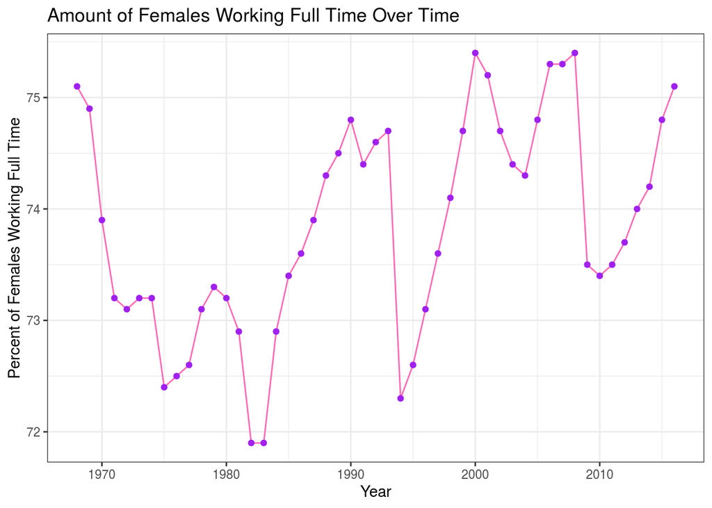

```r
employed_gender%>% #use employed gender part of data set
  ggplot()+ #use ggplot
  aes(x=year,
      y=full_time_female)+ #year on x, amount of females on y
  geom_line(color= "hotpink")+ #make a line plot with a pink line
  geom_point(color= "purple")+ #add purple points to the line
  theme_bw()+ #change the theme
  labs(x= "Year",
       y= "Percent of Females Working Full Time",
       title= "Amount of Females Working Full Time Over Time") #change the labels and add a title
```

### Answer

The amount of females working full time has gone up and down over the years, but ended up in generally the same spot.

## Question 2

### Methods

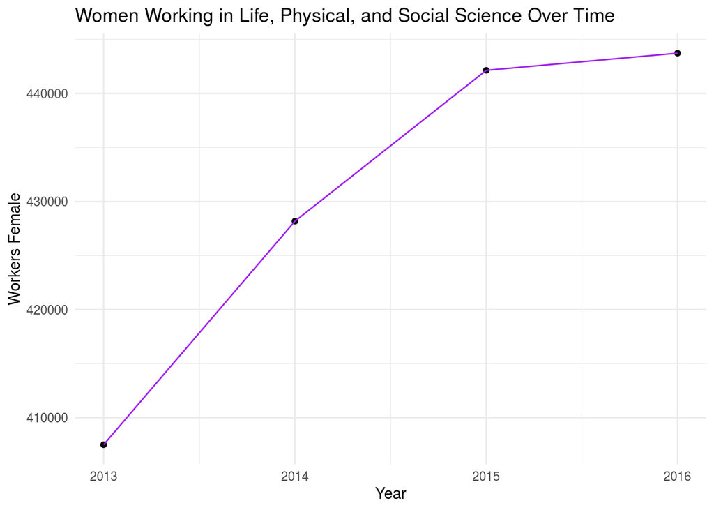

```r
jobs_gender%>% #using the jobs_gender tibble
  select(year, minor_category, workers_female)%>% #only want to look at these columns
  filter(minor_category== "Life, Physical, and Social Science")%>% #only want to see women in life physical and social science
  group_by(year)%>% #group by the year
  summarize(workers_female=sum(workers_female))%>% #find the amount of women for each year
  ggplot()+ #use ggplot
  aes(x=year,
      y= workers_female)+ #year on x, female workers on y
  geom_point()+ #have points on the plot
  geom_line(color= "purple")+ #make a line plot
  theme_minimal()+ #change the theme
  labs(x="Year",
       y="Workers Female",
       title= "Women Working in Life, Physical, and Social Science Over Time") #change labels and add a title
```

### Answer

The amount of women working in life, physical, and social science over time has increased since 2013.

## Question 3

### Methods

[figure not shown]

```r
jobs_gender%>%
  select(major_category, total_earnings_male, total_earnings_female)%>%
  rename(Male=total_earnings_male)%>% #rename male earnings
  rename(Female=total_earnings_female)%>% #rename female earnings
  pivot_longer(cols=c("Male","Female"), #pivot to a longer tibble
               names_to = "gender", #put the column names to new column named gender
               values_to = "earnings")%>% #put the earnings into a new column called earnings
  drop_na()%>% #drop the NAs
  group_by(gender)%>% #group by male or female
  summarise(mean_earnings=mean(earnings))%>% #find average earnings for each gender in service industry
  ggplot()+ #use ggplot
  aes(x=gender,
      y=mean_earnings,
      fill=gender)+ #gender on x, earnings on y, fill to gender
  geom_col()+#make a bar plot
  labs(x="Gender",
       y="Mean Earnings($)",
       title= "Male and Female Earnings in the Service Industy")+ #change labels and add title
  scale_fill_brewer(palette="Accent")+ #change colors
  theme_minimal()+ #change theme
  theme(legend.position = "none") #get rid of the legend
```

## Question 4

#### How has the amount of women biological scientists changed over the years?

### Methods

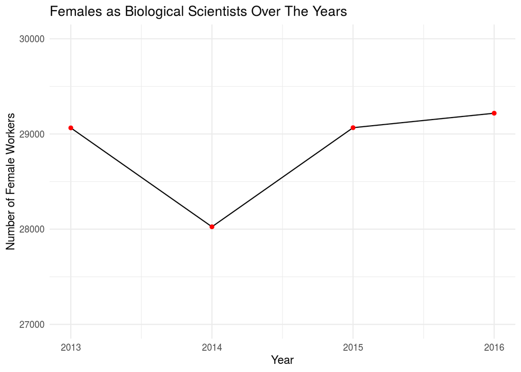

```r
jobs_gender%>% #using jobs gender tibble
  select(year, occupation, workers_female)%>% #only use the year, occupations, and workers female columns
  filter(occupation=="Biological scientists")%>% #only show women who are biological scienctists
  ggplot()+ #use ggplot
  aes(x=year,
      y=workers_female)+ #year on x, female workers on y
  geom_line()+ #make line plot
  geom_point(color="red")+ #add red points to the plot
  theme_minimal()+ #change theme
  labs(x= "Year",
       y="Number of Female Workers",
       title="Females as Biological Scientists Over The Years")+ #change labels add title
  ylim(27000,30000) #change y limit so the graph isnt misleading
```

### Answer

Females as biological scientists took a small dip in 2014, but overall, the amount of females has increased slighlty from 2013 to 2016.